# Praca domowa 7

Ola Paluszynska

8 maja 2017

# Cel pracy

## Dane

Będziemy korzystać ze zbioru danych `dementia` z pakietu `PBImisc`:

```r
library(PBImisc)
library(lme4)
library(ggplot2)
head(dementia)
```

```
##   demscore  age    sex         study
## 1       53  <60   Male Poland Gdansk
## 2       36  <60   Male Poland Gdansk
## 3       74 >=60 Female Poland Gdansk
## 4       39 >=60   Male Poland Gdansk
## 5       63  <60 Female Poland Gdansk
## 6       55 >=60   Male Poland Gdansk
```

```r
summary(dementia)
```

```
##     demscore       age          sex                    study
##  Min.   :  0.0   <60 :488   Female:498   Albania          :100
##  1st Qu.: 38.0   >=60:512   Male  :502   Estonia          :100
##  Median : 50.0                           Poland Gdansk    :100
##  Mean   : 50.5                           Poland Steszew   :100
##  3rd Qu.: 63.0                           Poland Swiebodzin:100
##  Max.   :100.0                           Poland Tarnobrzeg:100
##                                          (Other)          :400
```

## Model podstawowy

Na zajęciach rozpatrywaliśmy model wyjściowy uwzględniający losowy wyraz wolny ze względu na zmienną `study` (stwierdziliśmy, że jest on istotny) oraz efekty stałe `age` i `sex`, których istotność zbadamy poniżej.

```r
fixed_age_sex <- lmer(demscore ~ age + sex + (1 | study), data = dementia)
```

## Istotność efektów stałych

### Test Walda

Test Walda daje następujący wynik:

```r
df <- summary(fixed_age_sex)$coefficients
data.frame(df, p_value = 2*pnorm(abs(df[, 3]), lower.tail = FALSE))
```

```
##              Estimate Std..Error   t.value       p_value
## (Intercept)  50.58678  1.4171130  35.69707 4.389382e-279
## age>=60      10.30601  0.9853830  10.45888  1.334190e-25
## sexMale     -10.68218  0.9897844 -10.79243  3.737566e-27
```

Jak widać, przy każdym sensownym poziomie istotności stwierdzamy isotoność obu efektów stałych.

### Test ilorazu wiarygodności

W celu wykonania testu ilorazu wiarygodności wyznaczana jest wartość funkcji wiarygodności dla odpowiednich modeli zagnieżdżonych dopasowanych za pomocą ML (nie REML):

```r
fixed_sex <- lmer(demscore ~ sex + (1 | study), data = dementia)
fixed_age <- lmer(demscore ~ age + (1 | study), data = dementia)
anova(fixed_age_sex, fixed_sex)
```

```
## Data: dementia
## Models:
## fixed_sex: demscore ~ sex + (1 | study)
## fixed_age_sex: demscore ~ age + sex + (1 | study)
##               Df    AIC    BIC  logLik deviance  Chisq Chi Df Pr(>Chisq)
## fixed_sex      4 8447.9 8467.5 -4220.0   8439.9
## fixed_age_sex  5 8345.8 8370.3 -4167.9   8335.8 104.13      1  < 2.2e-16
##
## fixed_sex
## fixed_age_sex ***
## ---
## Signif. codes:  0 '***' 0.001 '**' 0.01 '*' 0.05 '.' 0.1 ' ' 1
```

```r
anova(fixed_age_sex, fixed_age)
```

```
## Data: dementia
## Models:
## fixed_age: demscore ~ age + (1 | study)
## fixed_age_sex: demscore ~ age + sex + (1 | study)
##               Df    AIC    BIC  logLik deviance  Chisq Chi Df Pr(>Chisq)
## fixed_age      4 8454.3 8473.9 -4223.1   8446.3
## fixed_age_sex  5 8345.8 8370.3 -4167.9   8335.8 110.51      1  < 2.2e-16
##
## fixed_age
## fixed_age_sex ***
## ---
## Signif. codes:  0 '***' 0.001 '**' 0.01 '*' 0.05 '.' 0.1 ' ' 1
```

Przy każdym sensownym poziomie istotności odrzucamy hipotezę zerową o tym, że mniejszy model jest równie dobrze dopasowany jak większy, co świadczy o istotności obu efektów stałych.

### Test permutacyjny

Poniżej przeprowadzamy test permutacyjny istotności efektu stałego `age` – za każdym razem permutujemy wartości zmiennej i zapisujemy wartość oszacowanego efektu.

```r
r <- 1000
data <- dementia
wynik <- replicate(r-1, {
  data$age_permuted <- sample(dementia$age)
  model <- lmer(demscore ~ age_permuted + sex + (1 | study), data = data)
  model@beta[2]
})
wynik <- c(wynik, fixed_age_sex@beta[2])
wynik[r] > quantile(wynik, 0.95) # test jednostronny: czy istotne przy poziomie istotności 0.05?
```

```
##  95%
## TRUE
```

Powyżej pokazaliśmy istotność tego efektu przy poziomie istotności 0.05. Poniżej pokazujemy rozkład oszacowania na histogramie i zaznaczamy na czerwono wartość w modelu bez permutacji, która jest wyraźnie oddalona od pozostałych wartości:

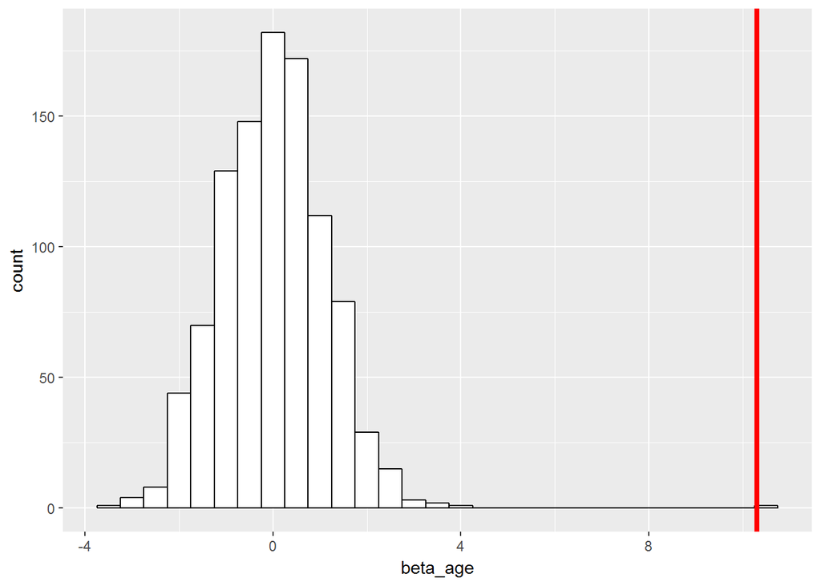

```r
ggplot(data.frame(beta_age = wynik), aes(x = beta_age)) + geom_histogram(binwidth = 0.5, color = "black", fill = "white") + geom_vline(xintercept = wynik[r], size = 1.5, color = "red")
```

Teraz przeprowadzamy tę samą procedurę dla efektu stałego `sex` co prowadzi do stwierdzenia, że jest on istotny:

```r
r <- 1000
data <- dementia
wynik <- replicate(r-1, {
  data$sex_permuted <- sample(dementia$sex)
  model <- lmer(demscore ~ age + sex_permuted + (1 | study), data = data)
  model@beta[3]
})
wynik <- c(wynik, fixed_age_sex@beta[3])
wynik[r] < quantile(wynik, 0.05) # czy istotne przy poziomie istotności 0.05?
```

```
##   5%
## TRUE
```

Powyżej pokazaliśmy istotność tego efektu przy poziomie istotności 0.05. Poniżej pokazujemy rozkład oszacowania na histogramie i zaznaczamy na czerwono wartość w modelu bez permutacji, która jest wyraźnie oddalona od pozostałych wartości:

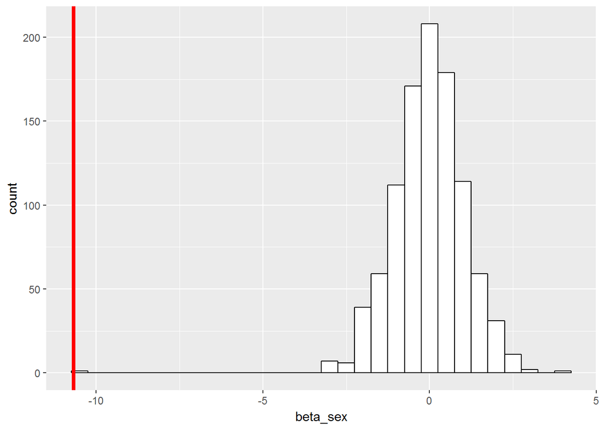

```r
ggplot(data.frame(beta_sex = wynik), aes(x = beta_sex)) + geom_histogram(binwidth = 0.5, color = "black", fill = "white") + geom_vline(xintercept = wynik[r], size = 1.5, color = "red")
```

## Istotność efektów losowych

Teraz będziemy rozważać losowe współczynniki przy zmiennych `age` i `sex`, w tym celu budujemy dwa modele:

```r
dementia$age_bin <- as.numeric(dementia$age == ">=60")
dementia$sex_bin <- as.numeric(dementia$sex == "Female")
fixed_age_sex_random_age <- lmer(demscore ~ age + sex + (age_bin | study), data = dementia)
fixed_age_sex_random_sex <- lmer(demscore ~ age + sex + (sex_bin | study), data = dementia)
```

### Test ilorazu wiarygodności

Przeprowadzamy test ilorazu wiarygodności dla obu efektów:

```r
anova(fixed_age_sex, fixed_age_sex_random_age)
```

```
## Data: dementia
## Models:
## fixed_age_sex: demscore ~ age + sex + (1 | study)
## fixed_age_sex_random_age: demscore ~ age + sex + (age_bin | study)
##                          Df    AIC    BIC  logLik deviance  Chisq Chi Df
## fixed_age_sex             5 8345.8 8370.3 -4167.9   8335.8
## fixed_age_sex_random_age  7 8309.0 8343.3 -4147.5   8295.0 40.802      2
##                          Pr(>Chisq)
## fixed_age_sex
## fixed_age_sex_random_age   1.38e-09 ***
## ---
## Signif. codes:  0 '***' 0.001 '**' 0.01 '*' 0.05 '.' 0.1 ' ' 1
```

```r
anova(fixed_age_sex, fixed_age_sex_random_sex)
```

```
## Data: dementia
## Models:
## fixed_age_sex: demscore ~ age + sex + (1 | study)
## fixed_age_sex_random_sex: demscore ~ age + sex + (sex_bin | study)
##                          Df    AIC    BIC  logLik deviance  Chisq Chi Df
## fixed_age_sex             5 8345.8 8370.3 -4167.9   8335.8
## fixed_age_sex_random_sex  7 8349.2 8383.6 -4167.6   8335.2 0.5337      2
##                          Pr(>Chisq)
## fixed_age_sex
## fixed_age_sex_random_sex     0.7658
```

Powyżej widać, że efekt losowy współczynnika przy zmiennej `age` jest istotny (przy każdym rozsądnym poziomie istotności), czego nie można powiedzieć o analogicznym efekcie zmiennej `sex`.

### Test permutacyjny

Przy badaniu istotności efektów losowych testem permutacyjnym patrzymy się nie na oszacowanie parametru beta (gdzyż takowego nie szacujemy), ale na oszacowanie wariancji efektu losowego, co robimy poniżej dla zmiennej `age`.

```r
r <- 1000
data <- dementia
wynik <- replicate(r-1, {
  data$study_permuted <- sample(dementia$study)
  model <-
    lmer(demscore ~ age + sex + (1 | study) + (age_bin - 1 | study_permuted), data = data)
  (model@theta[2] * summary(model)$sigma)^2
})
wynik <- c(wynik, (fixed_age_sex_random_age@theta[2] *
                     summary(fixed_age_sex_random_age)$sigma)^2)
wynik[r] > quantile(wynik, 0.95) # czy istotne przy poziomie istotności 0.05?
```

```
##  95%
## TRUE
```

Test permutacyjny potwierdza istotność losowego współczynnika przy zmiennej `age`, co ilustrujemy poniższym histogramem (warto zwrócić uwagę na wysoki słupek wartości zero powstały w wyniku znalezienia się oszacowań na granicy wartości parametrów):

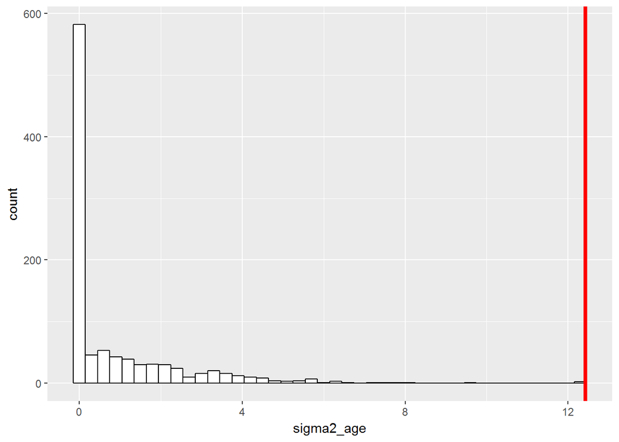

```r
ggplot(data.frame(sigma2_age = wynik), aes(x = sigma2_age)) + geom_histogram(binwidth = 0.3, color = "black", fill = "white") + geom_vline(xintercept = wynik[r], size = 1.5, color = "red")
```

Powtarzamy powyższą procedurę dla efektu losowego odpowiadającego zmiennej `sex`:

```r
r <- 1000
data <- dementia
wynik <- replicate(r-1, {
  data$study_permuted <- sample(dementia$study)
  model <-
    lmer(demscore ~ age + sex + (1 | study) + (sex_bin - 1 | study_permuted), data = data)
  (model@theta[2] * summary(model)$sigma)^2
})
wynik <- c(wynik, (fixed_age_sex_random_sex@theta[2] *
                     summary(fixed_age_sex_random_sex)$sigma)^2)
wynik[r] > quantile(wynik, 0.95) # czy istotne przy poziomie istotności 0.05?
```

```
##   95%
## FALSE
```

Również w tym przypadku wynik testu permutacyjnego potwierdza wynik testu ilorazu wiarygodności – efekt losowy nie jest istotny, co można zilustrować histogramem:

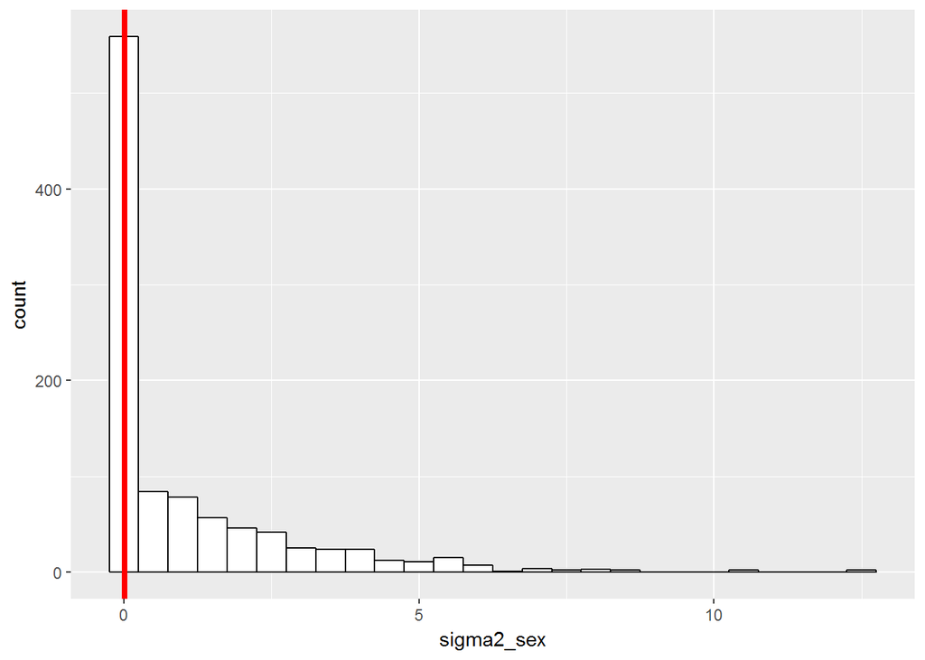

```r
ggplot(data.frame(sigma2_sex = wynik), aes(x = sigma2_sex)) + geom_histogram(binwidth = 0.5, color = "black", fill = "white") + geom_vline(xintercept = wynik[r], size = 1.5, color = "red")
```